# Trabajo Clasificación con la regresión logística: Primera parte.

Nombre: Jairo

Apellidos: Peña Iglesias

## Primer conjunto de datos: frontera de decisión lineal.

Vamos a empezar con un primer conjunto. El fichero que contiene los datos es ejemplo-logistica-1.csv que se puede descargar del Aula Virtual y guardar en la carpeta data del directorio asociado a nuestro nuevo proyecto.

Cargar los datos en un dataframe llamado **datos**

```r
# Completar aqui
datos <- read.table(file = "data/ejemplo-logistica-1.csv",
                    header =  TRUE,
                    sep = ";",
                    dec = ".",
                    stringsAsFactors = FALSE)
```

El conjunto presenta dos características x1 y x2, que queremos usar para poder predecir la variable binaria y.

Llevad a cabo la representación gráfica del conjunto, usando un color distinto para distinguir entre los valores de y.

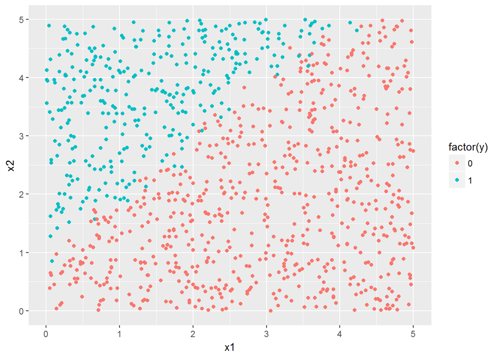

```r
# Completar aquí
datos %>%
 ggplot(aes(x = x1, y = x2)) + geom_point(aes(colour = factor(y)))
```

## Ajuste paso a paso de una regresión logística.

En esta parte, vamos a aprender a ajustar una regresión logística a nuestros datos.

Lo haremos en varias etapas…

### Implementación de la función logística.

Recordar que la función logística que sirve de base para nuestro ajuste a datos binarios, es (ver transparencias):
$$g(z)=\frac 1 {1+e^{-z}}.$$
Definir una función g, que admita como argumento un vector z y que devuelva el vector de valores de la función g(z)

```r
g= function (z)
  {
  ## Completar aquí para calcular g.tmp. Pagina19 (Trasparencia 33).
  g.tmp = 1/(1+exp(-z))

return(g.tmp)
}
```

Realizamos la gráfica de la curva

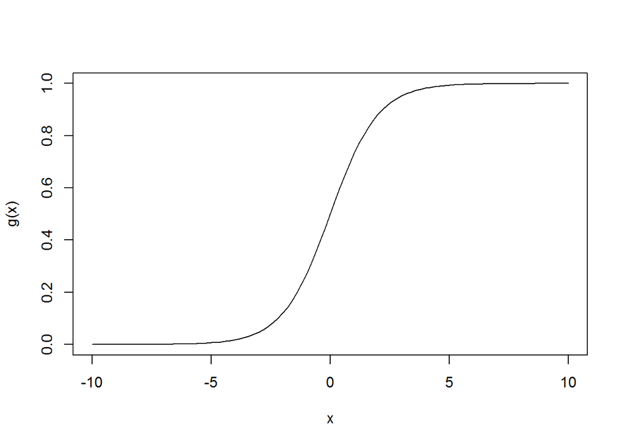

```r
## nada que completar
curve(g, from = -10, to = 10)
```

### Implementación de la función coste

Vamos ahora a implementar la función coste que llamaremos J. En las transparencias, encontramos la expresión para esa función coste en el caso de la regresión logística (recordad que los datos y_i son datos binarios)
$$J(\theta)=- \frac 1 n\sum_{i=1}^n \left\{y_i\log(h_\theta(x_{i\bullet}))+(1-y_i)\log(1-h_\theta(x_{i\bullet}))\right\}$$

Empezamos por crear la matriz x.mat de diseño así como el vector y de observaciones para poder usarlos en la definición de la función de coste.

```r
## nada que completar
x.mat <- cbind(1, as.matrix(datos %>% select(-y)))
y <- datos$y
```

```r
J=function(theta)
  {
  ## Completar aquí para calcular J.tmp. Pagina 38 (Trasparencia 59)
  J.tmp = (-1/length(y)) * sum(y * log(g(x.mat%*%theta)) + (1-y) * log(1-g(x.mat%*%theta)))

  ##
  return(J.tmp)
  }
```

Podemos probar algunos valores de theta para comprobar vuestra implementación: Para J(c(0,0,0)) debéis encontrar 0.6931. Para J(c(-0.5,-0.5,0.5)), debéis encontrar 0.3724.

### Implementación de la función gradiente del coste

Para poder usar algorítmos de búsqueda del mínimo de la función de coste, implementaremos también la función gradiente del coste, cuya expresión es (ver transparencias)

Si usamos la matriz de diseño $\mathbf{X}$, obtenemos en forma compacta:
$$\nabla J=\frac 1 n \mathbf{X}^T\cdot\left(\mathbf{H}_\theta-y\right),$$
donde $\mathbf{H}$ denota el vector columna:
$$\mathbf{H}_\theta=\left(
\begin{array}{l}
h_\theta(x_{1\bullet})\\
h_\theta(x_{2\bullet})\\
\vdots\\
h_\theta(x_{n\bullet})\\
\end{array}\right)$$

```r
gradJ=function(theta)
  {
  # teneís que calcular el gradiente aquí. Pagina 40 (trasparencia 63)
  gradJ = (1/length(y)) * (t(x.mat) %*% (g(x.mat %*% theta) - y))
  return(gradJ)
  }
```

### Búsqueda del mínimo

Una vez que tenemos implementada la función de coste, podemos escribir el código para una búsqueda del mínimo. Usaremos, en lugar de programar nosotros mismos el algoritmo del gradiente, la función optim() de R, que implementa métodos optimizados de búsqueda del mínimo. Especificamos como argumentos la función que queremos minimizar (argumento fn), su gradiente (argumento gr) y el método que queremos emplear (argumento method). Usaremos el método BFGS que consiste en una mejora del método del gradiente. También tenemos que especificar valores iniciales de los parámetros

```r
## nada que completar
optim.results=optim(c(0,0,0), fn=J, gr=gradJ, method = "BFGS")
```

Guardamos los resultados del algoritmo de minimización en un vector que llamamos thetaopt.

```r
## nada que completar
thetaopt=optim.results$par
```

En la gráfica que teníamos del conjunto, añadir la frontera de decisión…. (usar el geom: geom_abline)

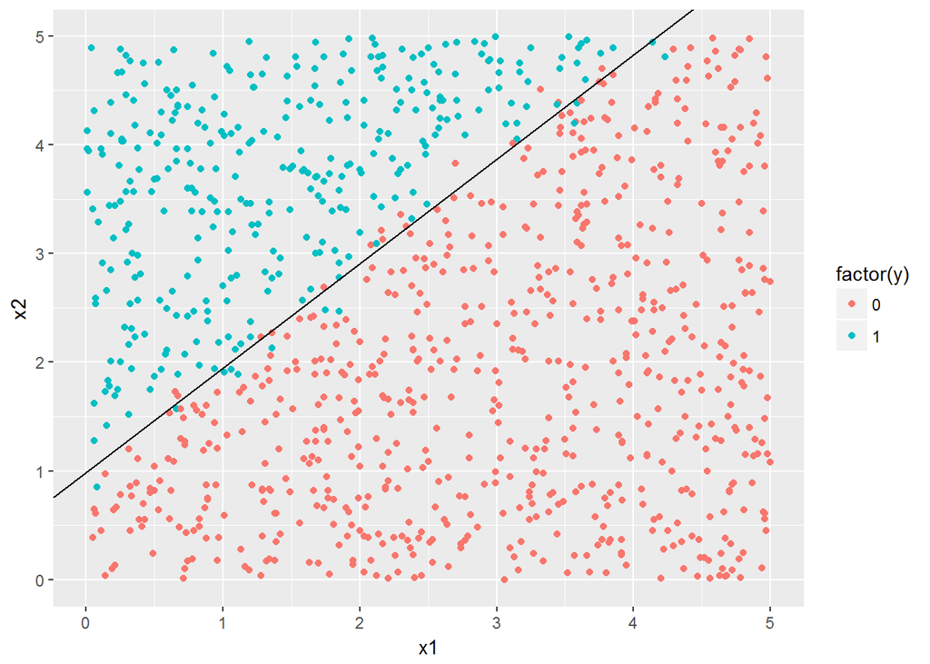

```r
## Completar aquí. Pagina 30 (Trasparencia 47)
datos %>%
 ggplot(aes(x = x1, y = x2)) + geom_point(aes(colour = factor(y))) +
  geom_abline(intercept = -(thetaopt[2]/thetaopt[3]), slope = -(thetaopt[1]/thetaopt[3])) #resuelvo la ecuación de theta (que es una recta)
```

```r
## intercept <- punto de corte
## slope <- pendiente
```

### Evaluación de la clasificación sobre el conjunto de entrenamiento

Añadimos a datos una columna que llamaremos yfit con los resultados de nuestro algoritmo de clasificación

```r
## Completad aquí. Pagina 27 (Trasparencia 44)
datos <- datos %>%
  mutate(yfit = as.numeric(g(x.mat %*% thetaopt) > 0.5))
## yfit <- probabilidad que encuentro de que sea 1. Es la probabilidad entre (0,1), es decir el redondeo de g
## para cada indivuduo de los valores <- x.mat
## el resultado del algoritmo <- thetaopt
```

Hacemos una tabla cruzada de los valores de y y los de yfit

```r
## completar aquí
table(datos$y, datos$yfit)
```

```
##
##       0   1
##   0 659  12
##   1  14 315
```

Qué número de Falsos positivos y falsos negativos hemos obtenido respectivamente? Hemos obtenido 12 falsos positivos y 14 falsos negativos. Por lo que tengo 659 datos que son negativos y 315 datos que son positivos.

¿Qué proporción de falsos positivos y falsos negativos hemos obtenido? Es decir, entre todos las observaciones que hemos clasificado como 1 (Positivos), ¿cuántos eran en realidad 0? y entre todas las observaciones que hemos clasificado como 0 (Negativos) ¿cuántos eran en realidad 1? (Podéis usar la instrucción prop.table aplicada a la tabla anterior…)

```r
## Completad aquí
prop.table(table(datos$y, datos$yfit), margin = 2)
```

```
##
##              0          1
##   0 0.97919762 0.03669725
##   1 0.02080238 0.96330275
```

## Segundo conjunto de datos: frontera de decisión cuadrática

En este apartado, se realizará el ajuste de una regresión logística para los datos contenidos en el fichero ejemplo-logistica-2.csv, pero se realizará añadiendo a la matriz de diseño las columnas que corresponden a los cuadrados de x1 y x2.

Cargar los datos en un dataframe llamado **datos**

```r
# Completar aqui
datos <- read.table(file = "data/ejemplo-logistica-2.csv",
                      header = TRUE,
                      sep = ";",
                      dec = ".",
                      stringsAsFactors = FALSE)
```

Llevad a cabo la representación gráfica del conjunto, usando un color distinto para distinguir entre los valores de y.

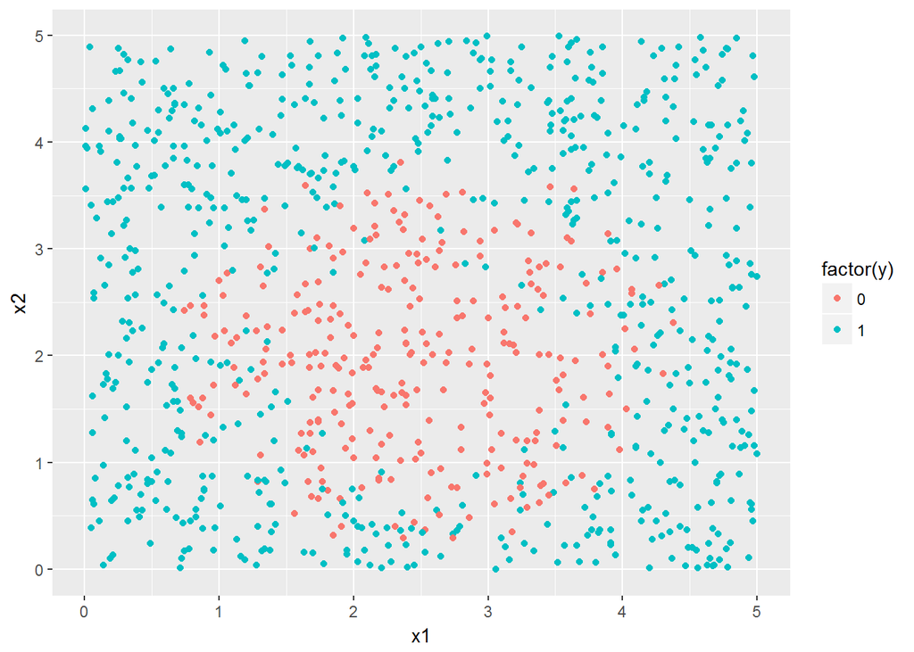

```r
# Completar aquí
datos %>%
 ggplot(aes(x = x1, y = x2)) + geom_point(aes(colour = factor(y)))
```

Empezamos por crear la matriz x.mat de diseño así como el vector y de observaciones para poder usarlos en la definición de la función de coste. Para ello, tendréis que añadir las columnas que contengan los cuadrados de x1 y de x2.

```r
## Completad aquí para construir x.mat e y.
x.mat <- cbind(1, as.matrix(datos %>%
                              mutate(x1cuadrado = x1^2,
                                     x2cuadrado = x2^2) %>%
                              select(-y)))
y <- datos$y
```

Usad la funció optim de R, para encontrar el mínimo de la función coste, al igual que en la sección anterior. Cuidado con el vector con el que hay que inicializar el algoritmo! (De qué longitud debe ser?) Su tamaño debe ser 5 ya que tenemos 5 columnas.

```r
## Completad aquí para encontrar optim.results
optim.results=optim(c(0,0,0,0,0), fn=J, gr=gradJ, method = "BFGS")
```

Guardamos los resultados del algoritmo de minimización en un vector que llamamos thetaopt.

```r
## nada que completar
thetaopt=optim.results$par
```

Cuál es la ecuación de la frontera de decisión?

¿Cuál es la forma de la frontera de decisión? Se trata de un circulo.

En la gráfica que teníamos del conjunto, vamos a añadir la frontera de decisión.

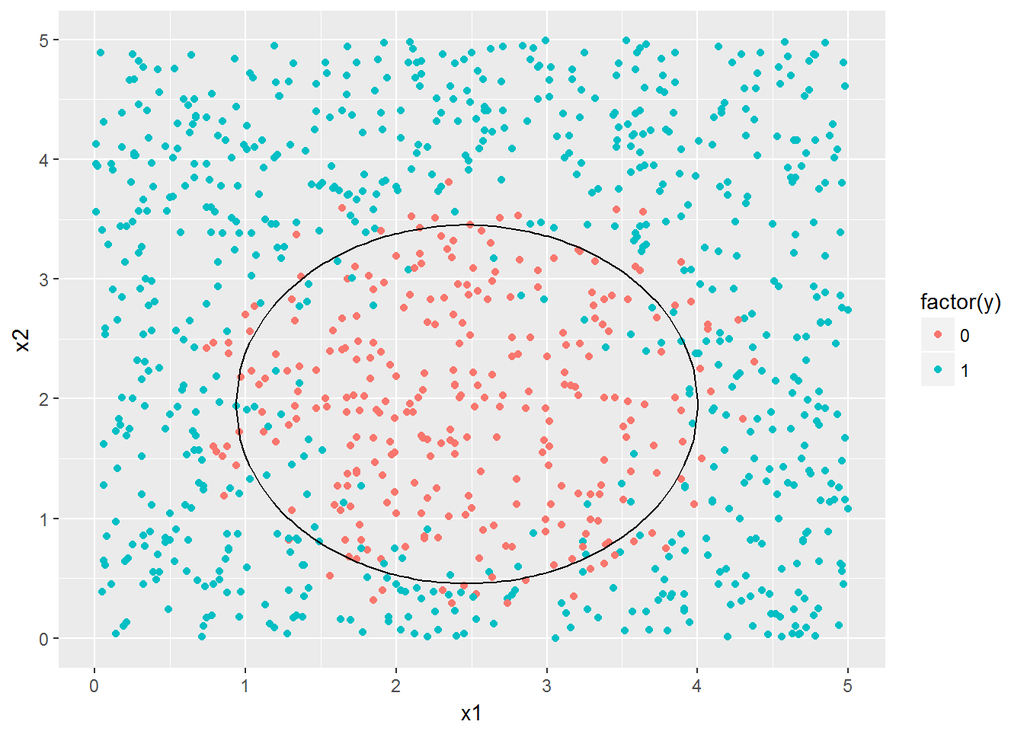

```r
## Nada que completar aquí
m1 <- - thetaopt[2] / (2 * thetaopt[4])
m2 <- - thetaopt[3] / (2 * thetaopt[5])
R2 <- thetaopt[2]^2 / (4 * thetaopt[4]) +
  thetaopt[3]^2 / (4 * thetaopt[5]) -
  thetaopt[1]
r1 <- sqrt(R2 / thetaopt[4])
r2 <- sqrt(R2 / thetaopt[5])
x1e <- seq(m1 - r1, m1 + r1, length.out = 100)
deltay1e <- sqrt(r2^2 * (1-(x1e-m1)^2 / r1^2))

elipse <- data.frame(x1 = c(x1e, rev(x1e)),
                     x2 = c(m2 + deltay1e,
                            m2 - deltay1e))
datos %>%
  ggplot(aes(x1, x2)) + geom_point(aes(colour = factor(y))) +
           geom_path(data = elipse)
```